# Histogram and Density

Wayne Oldford and Zehao Xu

2024-04-08

Histograms (and bar plots) are common tools to visualize a single variable. The x axis is often used to locate the bins and the y axis is for the counts. Density plots can be considered as the smoothed version of the histogram.

Boxplot is another method to visualize one dimensional data. Five summary statistics can be easily traced on the plot. However, compared with histograms and density plots, boxplot can accommodate two variables, `group`s (often on the `x` axis) and `y`s (on the `y` axis).

In `ggplot2`, `geom_histogram` and `geom_density` only accept one variable, `x` or `y` (swapped). Providing both positions is forbidden. Inspired by the boxplot (`geom_boxplot` in `ggplot2`), we create functions `geom_histogram_`, `geom_bar_` and `geom_density_` which can accommodate both variables, just like the `geom_boxplot`!

## Hist (histogram and bar plot)

### Two dimensional bar plot: `geom_bar_`

Consider the `mtcars` data set.

```r
mtcars2 <- mtcars %>%
  mutate(
    cyl = factor(cyl),
    gear  = factor(gear)
  )
```

Suppose that we are interested in the relationship of number of gears given the `cyl` (number of cylinders).

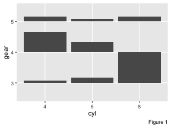

```r
library(ggmulti)
ggplot(mtcars2,
       mapping = aes(x = cyl, y = gear)) +
  geom_bar_(as.mix = TRUE) +
  labs(caption = "Figure 1")
```

Though the Figure 1, we can tell that

- Compare vertically: given the number of engines, tell the gears
  - Most V8 engine cars prefer 3 gear transmission. V8 cars do not use 4 gear transmission
  - Most V4 engine cars prefer 4 gears transmission.
- Compare horizontally: given the number of gears, tell the engines
  - Most 3 gear transmission cars carry a V8 engine.
  - Most 4 gear transmission cars carry a V4 engine, then V6 engine, but never V8 engine.
  - Five gear transmission cars can carry either a V4, V6 or V8 engine. However, compared with other two transmissions, 5 gear is not a common choice.

### Two dimensional histogram: `geom_histogram_`

Suppose now, we are interested in the distribution of `mpg` (miles per gallon) with the respect to the `cyl` (as “x” axis) and `gear` (as “fill”). Through the Figure 2, we can easily tell that as the number of cylinders rises, the miles/gallon drops significantly. Moreover, the number of six cylinder cars is much less that the other two in our data. In addition, the transmission of V8 cars is either 3 or 5 (identical to the conclusion we draw before).

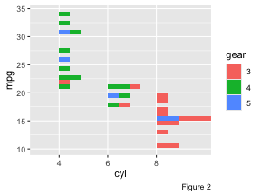

```r
g <- ggplot(mtcars2,
            mapping = aes(x = cyl,
                          y = mpg,
                          fill = gear)) +
  geom_histogram_(as.mix = TRUE) +
  labs(caption = "Figure 2")
g
```

### Just call `geom_hist`!

Function `geom_histogram_` is often used as one factor is categorical and the other is numerical, while function `geom_bar_` accommodate two categorical variables. The former one relies on **`stat = bin_`** and the latter one is on **`stat = count_`**. However, if we turn the factor of interest as numerical in `geom_bar_`, there would be no difference between the output of a bar plot and a histogram. Hence, function `geom_hist` is created by simplifying the process. It understands both cases and users can just call `geom_hist` to create either a bar plot or a histogram.

## Density

We could also draw density plot side by side to better convey the data of interest. With `geom_density_`, both summaries can be displayed simultaneously in one chart. Note that for cylinder 4 and 6, the density representing 3 gear transmission and 5 gear transmission cars are missing respectively. The reason is that for these two subgroups, the number of observations is not big enough to be used to compute the density.

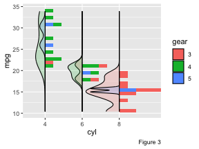

```r
g +
  # parameter "positive" controls where the summaries face to
  geom_density_(as.mix = TRUE,
                positive = FALSE,
                alpha = 0.2) +
  labs(caption = "Figure 3")
```

In Figure 3, an argument `as.mix` is set as `TRUE`. What does it mean? Before we introduce it, let us look at the total count of `cyl` in `mtcars`.

```r
tab <- table(mtcars2$cyl)
knitr::kable(
  data.frame(
    cyl = names(tab),
    count = unclass(tab),
    row.names = NULL
  )
)
```

| cyl | count |
| --- | --- |
| 4 | 11 |
| 6 | 7 |
| 8 | 14 |

In the sample, the total number of cylinder 8 cars is approximately twice as much as the group cylinder 6. Within each group, if the `as.mix` is set as `FALSE` (default), shown as Figure 4, the area for each subgroup (in general, one color represents one subgroup) is 1 and the whole area is **3** in total. There is no problem to think it as a real “density”, however, if we consider it as a “continuous histogram” (the binwidth is approaching 0), it may be misleading somehow. Instead, the `as.mix` could be set as `TRUE` so that the sum of the density area within each group is **1**. The area for each subgroup is proportional to the count, as Figure 5.

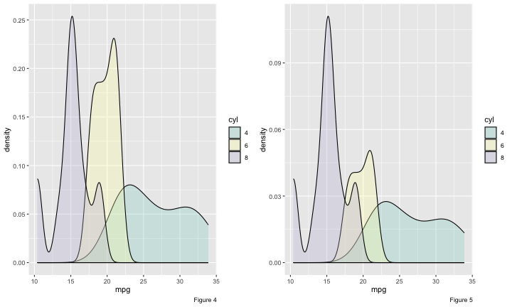

```r
gd1 <- ggplot(mtcars2,
              mapping = aes(x = mpg, fill = cyl)) +
  # it is equivalent to call `geom_density()`
  geom_density_(alpha = 0.3) +
  scale_fill_brewer(palette = "Set3") +
  labs(caption = "Figure 4")
gd2 <- ggplot(mtcars2,
              mapping = aes(x = mpg, fill = cyl)) +
  geom_density_(as.mix = TRUE, alpha = 0.3) +
  scale_fill_brewer(palette = "Set3") +
  labs(caption = "Figure 5")
gridExtra::grid.arrange(gd1, gd2, nrow = 1)
```

Additionally, function `geom_density_` (so does `geom_histogram_`) provides another parameter `scale.y` to set the scales across different groups (different cylinder types). The default `data` indicates that the area of each density estimates is proportional to the overall count. If the `scale.y` is set as `group`, regardless of the other groups, the density estimate of each subgroup is scaled respecting by its own group, as Figure 6. The benefit is that, within each group, the pattern of the density is easier to be visualized and compared. However, across different groups, it is *meaningless* to compare.

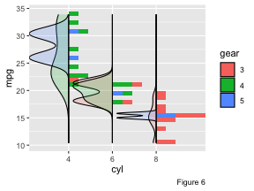

```r
g +
  # parameter "positive" controls where the summaries face to
  geom_density_(positive = FALSE,
                alpha = 0.2,
                scale.y = "group") +
  labs(caption = "Figure 6")
```